# What is the price of a House in the King County?

Sri Charan Bodduna

# Introduction

- We are going analyze King County data using multiple linear regression and find the best model with suitable explanatory variables and understand various performance parameters of the model.
- We will perform preliminary steps like data cleaning and exploration of the dataset.
- We will using Linear Regression models from TidyVerse package in R
- At the end, we are going to predict the price of the house for a given house characteristics.

# Problem Statement

1. What is the relationship between the living area (sqft_living) and the price of the house?
2. Does the number of floors have a significant effect on the house price?
3. What are the important variable that explains price of the house?

Assumptions

- There is a linear relationship between explanatory and target variable
- The errors follow the normal distribution
- No multicollinearity

# Data Understanding

1. The King County Housing Dataset contains information on the sales prices and characteristics of homes in Seattle and King County, Washington, from May 2014 to 2015.
2. The data set includes many different variables such as sales price, number of bedrooms, number of bathrooms, size of living space in square feet, land area in square feet, number of floors, waterfront indicator, view index, condition of the house, level, square feet above ground, square feet below ground, year of construction, year of renovation, zip code, latitude, and longitude.
3. The data set includes 21,613 observations and 21 variables. It can be used for a variety of analytics, including predicting real estate prices using regression methods.
4. Additionally, the Health and Housing Data Dashboard powered by King County provides comprehensive and summarized health and housing reports, including resident data from housing authorities.

# Import Libraries

```r
if (!require("ggplot2")) install.packages("ggplot2")
library("ggplot2")
if (!require("devtools")) install.packages("devtools")
library("devtools")
if (!require("tidyr")) install.packages("tidyr")
library("tidyr")
if (!require("dplyr")) install.packages("dplyr")
library("dplyr")
if (!require("gtsummary")) install.packages("gtsummary")
library("gtsummary")
if (!require("skimr")) install.packages("skimr")
library('skimr')
if (!require("broom")) install.packages("broom")
library("broom")
if (!require("GGally")) install.packages("GGally")
library(GGally)
if (!require("ggfortify")) install.packages("ggfortify")
library(ggfortify)
if (!require("car")) install.packages("car")
library(car)
```

# Data loading

```r
kc_house_data <- read.csv("kc_house_data.csv")

names(kc_house_data)
```

```
##  [1] "id"            "date"          "price"         "bedrooms"
##  [5] "bathrooms"     "sqft_living"   "sqft_lot"      "floors"
##  [9] "waterfront"    "view"          "condition"     "grade"
## [13] "sqft_above"    "sqft_basement" "yr_built"      "yr_renovated"
## [17] "zipcode"       "lat"           "long"          "sqft_living15"
## [21] "sqft_lot15"
```

# Data cleaning

```r
kc_house_data <- kc_house_data[-c(1,2 )]

# select(df, "price", "sqft_living","sqft_lot", "sqft_above", "sqft_basement", "sqft_living15","sqft_lot15")

kc_house_data <- filter(kc_house_data, zipcode == 98103)
```

# Data preprocessing

```r
is.na(kc_house_data) %>% colSums()
```

```
##         price      bedrooms     bathrooms   sqft_living      sqft_lot
##             0             0             0             0             0
##        floors    waterfront          view     condition         grade
##             0             0             0             0             0
##    sqft_above sqft_basement      yr_built  yr_renovated       zipcode
##             0             0             0             0             0
##           lat          long sqft_living15    sqft_lot15
##             0             0             0             0
```

```r
# colSums(kc_house_data)
kc_house_data <- kc_house_data[!duplicated(kc_house_data),]
```

# Subsets predictors

```r
kc_house_data %>% skim()
```

Data summary

| Name | Piped data |
| --- | --- |
| Number of rows | 602 |
| Number of columns | 19 |
| _______________________ |  |
| Column type frequency: |  |
| numeric | 19 |
| ________________________ |  |
| Group variables | None |

**Variable type: numeric**

| skim_variable | n_missing | complete_rate | mean | sd | p0 | p25 | p50 | p75 | p100 | hist |
| --- | --- | --- | --- | --- | --- | --- | --- | --- | --- | --- |
| price | 0 | 1 | 584919.21 | 208951.81 | 238000.00 | 432125.00 | 550000.00 | 695000.00 | 1695000.00 | ▇▇▂▁▁ |
| bedrooms | 0 | 1 | 3.06 | 1.56 | 1.00 | 2.00 | 3.00 | 3.00 | 33.00 | ▇▁▁▁▁ |
| bathrooms | 0 | 1 | 1.93 | 0.79 | 0.75 | 1.00 | 2.00 | 2.50 | 4.50 | ▇▇▅▂▁ |
| sqft_living | 0 | 1 | 1650.83 | 631.76 | 390.00 | 1242.50 | 1505.00 | 1960.00 | 4360.00 | ▃▇▂▁▁ |
| sqft_lot | 0 | 1 | 3482.45 | 1832.01 | 651.00 | 1563.25 | 3500.00 | 4800.00 | 9450.00 | ▇▇▆▂▁ |
| floors | 0 | 1 | 1.83 | 0.79 | 1.00 | 1.00 | 1.50 | 3.00 | 3.50 | ▇▂▁▃▁ |
| waterfront | 0 | 1 | 0.00 | 0.00 | 0.00 | 0.00 | 0.00 | 0.00 | 0.00 | ▁▁▇▁▁ |
| view | 0 | 1 | 0.14 | 0.61 | 0.00 | 0.00 | 0.00 | 0.00 | 4.00 | ▇▁▁▁▁ |
| condition | 0 | 1 | 3.48 | 0.74 | 1.00 | 3.00 | 3.00 | 4.00 | 5.00 | ▁▁▇▂▂ |
| grade | 0 | 1 | 7.41 | 0.76 | 5.00 | 7.00 | 7.00 | 8.00 | 11.00 | ▁▇▆▁▁ |
| sqft_above | 0 | 1 | 1405.04 | 487.30 | 390.00 | 1070.00 | 1365.00 | 1603.00 | 3920.00 | ▃▇▂▁▁ |
| sqft_basement | 0 | 1 | 245.79 | 366.81 | 0.00 | 0.00 | 0.00 | 480.00 | 1540.00 | ▇▁▂▁▁ |
| yr_built | 0 | 1 | 1953.09 | 41.54 | 1900.00 | 1917.25 | 1934.50 | 2005.00 | 2015.00 | ▇▅▂▁▇ |
| yr_renovated | 0 | 1 | 109.27 | 454.12 | 0.00 | 0.00 | 0.00 | 0.00 | 2014.00 | ▇▁▁▁▁ |
| zipcode | 0 | 1 | 98103.00 | 0.00 | 98103.00 | 98103.00 | 98103.00 | 98103.00 | 98103.00 | ▁▁▇▁▁ |
| lat | 0 | 1 | 47.68 | 0.02 | 47.65 | 47.66 | 47.68 | 47.69 | 47.70 | ▇▆▃▇▇ |
| long | 0 | 1 | -122.34 | 0.01 | -122.36 | -122.35 | -122.35 | -122.34 | -122.33 | ▁▆▇▆▅ |
| sqft_living15 | 0 | 1 | 1524.15 | 283.63 | 690.00 | 1330.00 | 1500.00 | 1700.00 | 2660.00 | ▁▇▇▂▁ |
| sqft_lot15 | 0 | 1 | 3472.32 | 1571.92 | 1026.00 | 1610.50 | 3850.00 | 4560.00 | 8431.00 | ▆▅▇▁▁ |

# EDA (1)

```r
str(kc_house_data)
```

```
## 'data.frame':    602 obs. of  19 variables:
##  $ price        : num  485000 570000 518500 822500 511000 ...
##  $ bedrooms     : int  4 3 3 5 3 3 4 2 3 2 ...
##  $ bathrooms    : num  1 1.75 3.5 3.5 1 2 1 1 1.75 1 ...
##  $ sqft_living  : int  1600 1260 1590 2320 1430 1360 1330 1030 1560 1470 ...
##  $ sqft_lot     : int  4300 3328 1102 4960 3455 3090 2400 3060 3000 3864 ...
##  $ floors       : num  1.5 1 3 2 1 2 1.5 1 1 1 ...
##  $ waterfront   : int  0 0 0 0 0 0 0 0 0 0 ...
##  $ view         : int  0 0 0 0 0 0 0 2 0 0 ...
##  $ condition    : int  4 5 3 5 3 3 4 4 4 4 ...
##  $ grade        : int  7 6 8 7 7 8 6 7 6 7 ...
##  $ sqft_above   : int  1600 700 1590 1720 980 1360 1330 790 770 1170 ...
##  $ sqft_basement: int  0 560 0 600 450 0 0 240 790 300 ...
##  $ yr_built     : int  1916 1905 2010 1926 1947 1990 1901 1918 1918 1916 ...
##  $ yr_renovated : int  0 0 0 0 0 0 0 0 0 0 ...
##  $ zipcode      : int  98103 98103 98103 98103 98103 98103 98103 98103 98103 98103 ...
##  $ lat          : num  47.7 47.7 47.7 47.7 47.7 ...
##  $ long         : num  -122 -122 -122 -122 -122 ...
##  $ sqft_living15: int  1610 1380 1620 1700 1450 1500 1330 1390 1390 1570 ...
##  $ sqft_lot15   : int  4300 3536 3166 4960 4599 3090 4400 3060 3000 3864 ...
```

# EDA

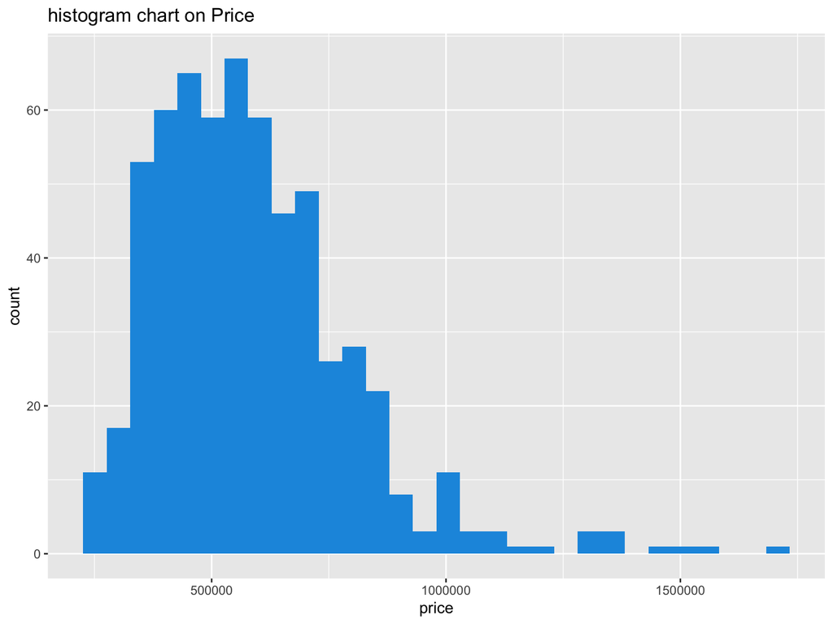

```r
ggplot(kc_house_data, aes(price)) +
  geom_histogram(fill="#1b98e0") +
  ggtitle("histogram chart on Price")
```

# Exploratory Data Analysis

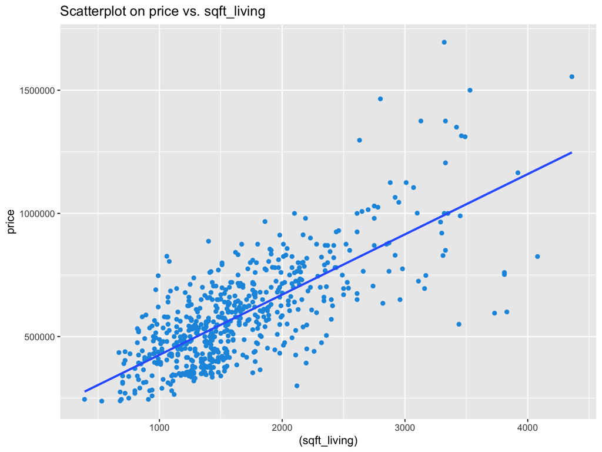

```r
ggplot(kc_house_data, aes(x = (sqft_living), y = price)) +
  geom_point(color="#1b98e0") +
  geom_smooth(method = 'lm', se=FALSE) +
  ggtitle("Scatterplot on price vs. sqft_living")
```

# EDA

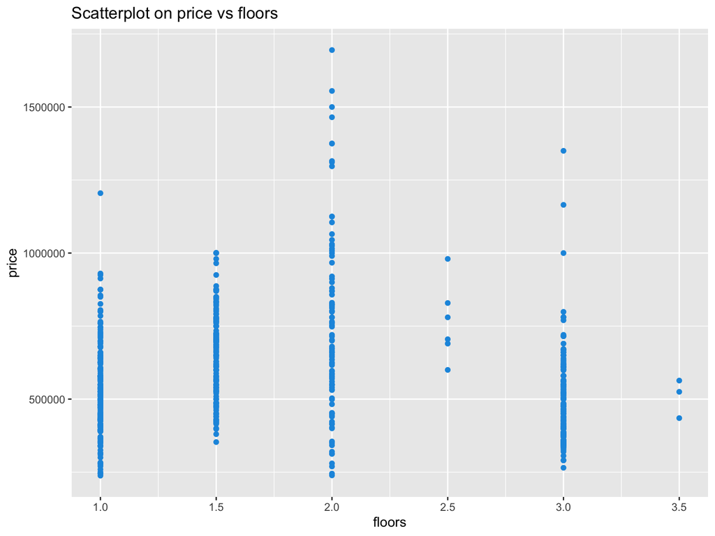

```r
ggplot(kc_house_data, aes(x = floors, y = price)) +
  geom_point(color="#1b98e0")+
  ggtitle("Scatterplot on price vs floors")
```

# EDA

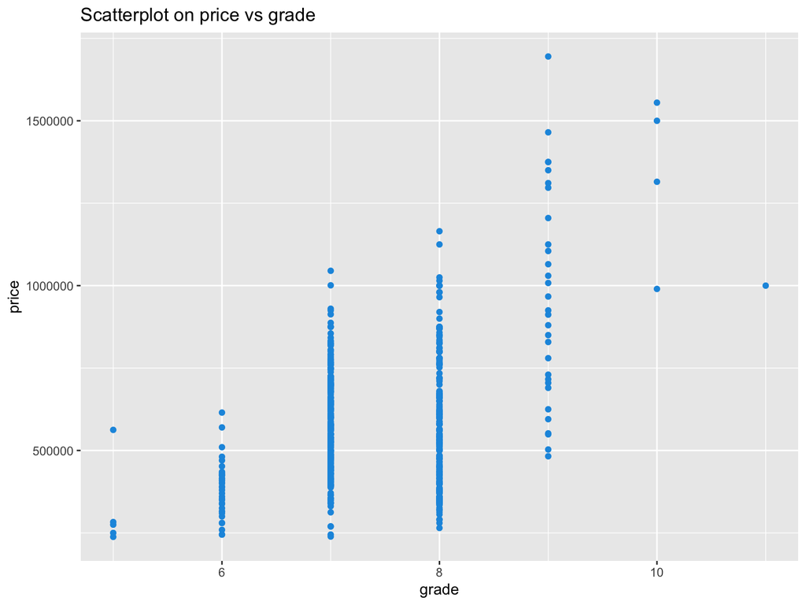

```r
ggplot(kc_house_data, aes(x = grade, y = price)) +
  geom_point(color="#1b98e0") +
  ggtitle("Scatterplot on price vs grade")
```

# EDA

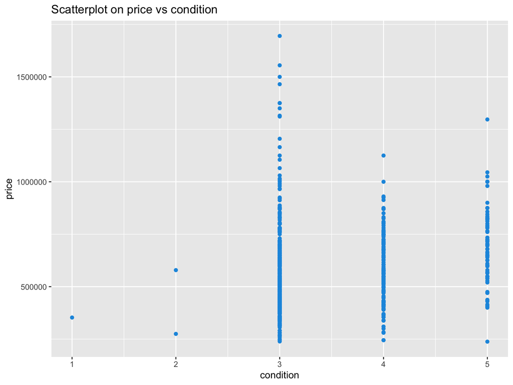

```r
ggplot(kc_house_data, aes(x = condition, y = price)) +
  geom_point(color="#1b98e0") +
  ggtitle("Scatterplot on price vs condition")
```

# EDA

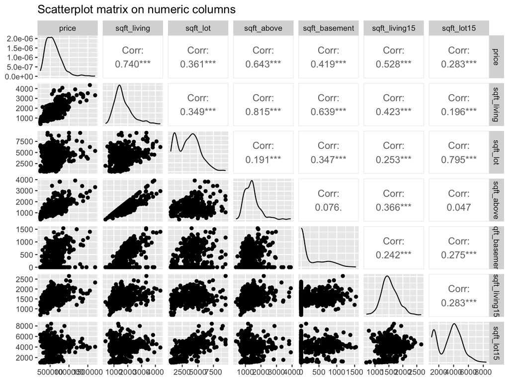

```r
ggpairs(select(kc_house_data, "price", "sqft_living","sqft_lot", "sqft_above", "sqft_basement", "sqft_living15","sqft_lot15")) +
  ggtitle("Scatterplot matrix on numeric columns")
```

# modeling(1)

## Model with all variables

```r
mdl_all <- lm(price ~  ., kc_house_data)

summary(mdl_all)
```

```
##
## Call:
## lm(formula = price ~ ., data = kc_house_data)
##
## Residuals:
##     Min      1Q  Median      3Q     Max
## -522149  -56411   -6524   52760  470046
##
## Coefficients: (3 not defined because of singularities)
##                 Estimate Std. Error t value Pr(>|t|)
## (Intercept)    4.895e+08  7.264e+07   6.739 3.82e-11 ***
## bedrooms      -1.262e+03  3.026e+03  -0.417  0.67688
## bathrooms      3.441e+03  9.031e+03   0.381  0.70331
## sqft_living    8.704e+01  1.600e+01   5.441 7.80e-08 ***
## sqft_lot       1.118e+01  4.530e+00   2.468  0.01389 *
## floors        -6.200e+04  1.197e+04  -5.179 3.07e-07 ***
## waterfront            NA         NA      NA       NA
## view           1.679e+04  7.349e+03   2.285  0.02266 *
## condition      3.362e+04  7.486e+03   4.492 8.50e-06 ***
## grade          9.911e+04  8.481e+03  11.686  < 2e-16 ***
## sqft_above     8.871e+01  1.890e+01   4.694 3.34e-06 ***
## sqft_basement         NA         NA      NA       NA
## yr_built       1.730e+02  2.209e+02   0.783  0.43390
## yr_renovated   2.944e+01  1.049e+01   2.806  0.00519 **
## zipcode               NA         NA      NA       NA
## lat           -3.612e+06  2.986e+05 -12.099  < 2e-16 ***
## long           2.601e+06  5.850e+05   4.446 1.05e-05 ***
## sqft_living15  6.051e+01  1.873e+01   3.231  0.00130 **
## sqft_lot15     1.272e+01  4.762e+00   2.671  0.00778 **
## ---
## Signif. codes:  0 '***' 0.001 '**' 0.01 '*' 0.05 '.' 0.1 ' ' 1
##
## Residual standard error: 101900 on 586 degrees of freedom
## Multiple R-squared:  0.7681, Adjusted R-squared:  0.7622
## F-statistic: 129.4 on 15 and 586 DF,  p-value: < 2.2e-16
```

# Model Validation(1)

## Model with all variables

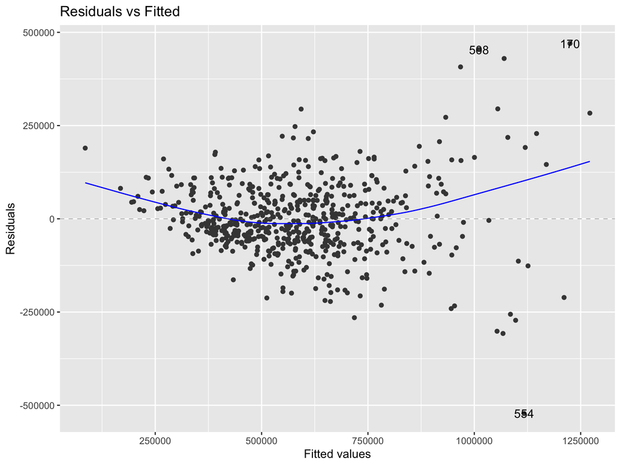

```r
autoplot(mdl_all, which=1, nrow=1, ncol= 1)
```

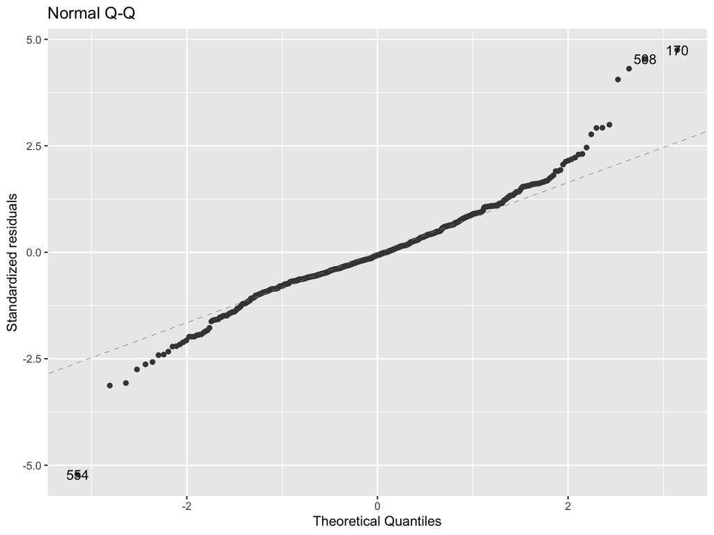

```r
autoplot(mdl_all, which=2, nrow=1, ncol= 1)
```

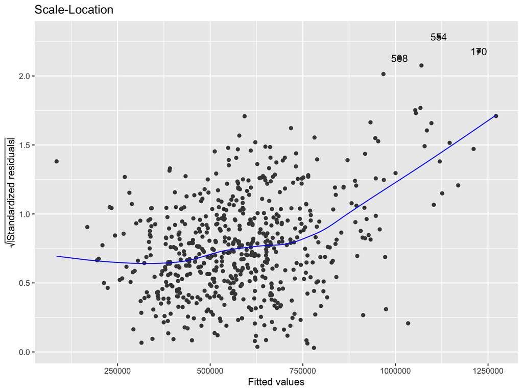

```r
autoplot(mdl_all, which=3, nrow=1, ncol= 1)
```

```r
# autoplot(m1, which=1, nrow=1, ncol= 1)
```

# Modeling(2) - stepwise model with important variables

```r
############

intercept_only <- lm(price ~ 1, data=kc_house_data)
all <- lm(price ~ ., data=kc_house_data)

both <- step(intercept_only, direction='both', scope=formula(all), trace=0)
both$anova
```

```
##               Step Df     Deviance Resid. Df   Resid. Dev      AIC
## 1                  NA           NA       601 2.624018e+13 14749.83
## 2    + sqft_living -1 1.435167e+13       600 1.188851e+13 14275.21
## 3            + lat -1 2.051891e+12       599 9.836618e+12 14163.16
## 4     + sqft_lot15 -1 1.022492e+12       598 8.814125e+12 14099.09
## 5          + grade -1 1.307240e+12       597 7.506886e+12 14004.44
## 6         + floors -1 4.347202e+11       596 7.072165e+12 13970.53
## 7     + sqft_above -1 2.763699e+11       595 6.795795e+12 13948.53
## 8  + sqft_living15 -1 1.911067e+11       594 6.604689e+12 13933.36
## 9      + condition -1 1.748002e+11       593 6.429889e+12 13919.22
## 10          + long -1 1.433530e+11       592 6.286536e+12 13907.64
## 11  + yr_renovated -1 7.615412e+10       591 6.210381e+12 13902.31
## 12      + sqft_lot -1 5.708727e+10       590 6.153294e+12 13898.75
## 13          + view -1 5.627982e+10       589 6.097014e+12 13895.21
```

```r
(both$coefficients)
```

```
##   (Intercept)   sqft_living           lat    sqft_lot15         grade
##  4.815634e+08  9.172236e+01 -3.534970e+06  1.296339e+01  1.021764e+05
##        floors    sqft_above sqft_living15     condition          long
## -5.599542e+04  8.339312e+01  5.872033e+01  3.049177e+04  2.563682e+06
##  yr_renovated      sqft_lot          view
##  2.590545e+01  1.058664e+01  1.708563e+04
```

```r
mdl_imp_vars <- lm(log(price) ~  (sqft_living) + lat+sqft_lot15+grade+floors+
         sqft_above+sqft_living15+condition+yr_renovated+sqft_lot + view, kc_house_data)
summary(mdl_imp_vars)
```

```
##
## Call:
## lm(formula = log(price) ~ (sqft_living) + lat + sqft_lot15 +
##     grade + floors + sqft_above + sqft_living15 + condition +
##     yr_renovated + sqft_lot + view, data = kc_house_data)
##
## Residuals:
##      Min       1Q   Median       3Q      Max
## -0.68175 -0.09896  0.00489  0.09636  0.47142
##
## Coefficients:
##                 Estimate Std. Error t value Pr(>|t|)
## (Intercept)    3.566e+02  2.120e+01  16.819  < 2e-16 ***
## sqft_living    1.390e-04  2.078e-05   6.688 5.25e-11 ***
## lat           -7.243e+00  4.446e-01 -16.290  < 2e-16 ***
## sqft_lot15     2.420e-05  7.390e-06   3.274 0.001122 **
## grade          1.504e-01  1.232e-02  12.211  < 2e-16 ***
## floors        -9.008e-02  1.581e-02  -5.698 1.92e-08 ***
## sqft_above     1.253e-04  2.822e-05   4.441 1.07e-05 ***
## sqft_living15  1.583e-04  2.798e-05   5.658 2.39e-08 ***
## condition      6.091e-02  9.964e-03   6.113 1.78e-09 ***
## yr_renovated   5.072e-05  1.467e-05   3.456 0.000588 ***
## sqft_lot       1.368e-05  6.984e-06   1.959 0.050539 .
## view           9.649e-03  1.093e-02   0.883 0.377808
## ---
## Signif. codes:  0 '***' 0.001 '**' 0.01 '*' 0.05 '.' 0.1 ' ' 1
##
## Residual standard error: 0.1583 on 590 degrees of freedom
## Multiple R-squared:  0.7813, Adjusted R-squared:  0.7772
## F-statistic: 191.6 on 11 and 590 DF,  p-value: < 2.2e-16
```

# Model Validation (2)

## Stepwise model with important variables

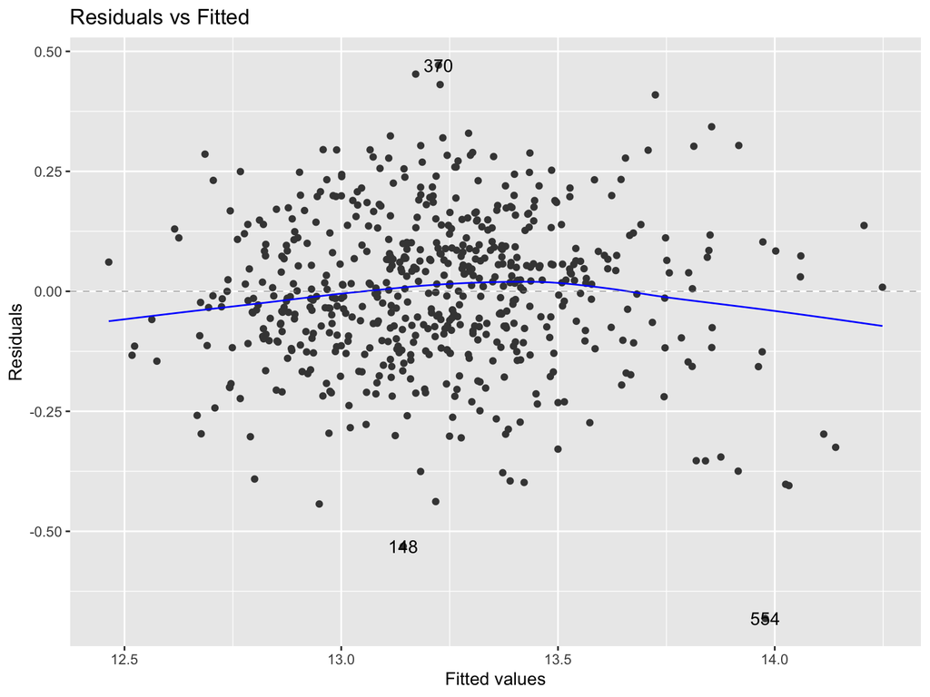

```r
autoplot(mdl_imp_vars, which=1, nrow=1, ncol= 1)
```

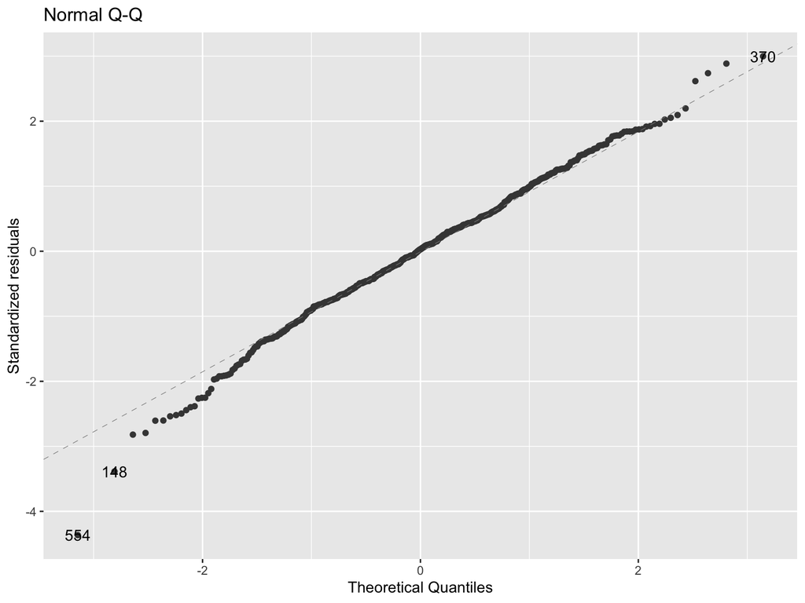

```r
autoplot(mdl_imp_vars, which=2, nrow=1, ncol= 1)
```

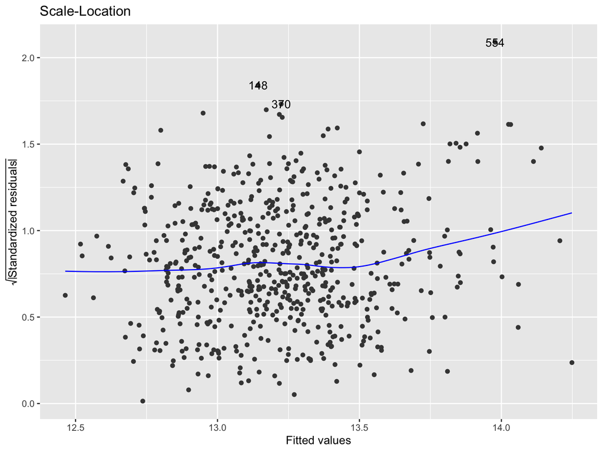

```r
autoplot(mdl_imp_vars, which=3, nrow=1, ncol= 1)
```

# Modeling(3)

## Model with minimum variables

```r
mdl_min_vars <- lm(price ~  sqft_living+ floors + grade + condition + sqft_above +
         sqft_living15 + yr_renovated, kc_house_data)
summary(mdl_min_vars)
```

```
##
## Call:
## lm(formula = price ~ sqft_living + floors + grade + condition +
##     sqft_above + sqft_living15 + yr_renovated, data = kc_house_data)
##
## Residuals:
##     Min      1Q  Median      3Q     Max
## -499979  -71575     -80   67328  496502
##
## Coefficients:
##                 Estimate Std. Error t value Pr(>|t|)
## (Intercept)   -658601.28   66654.58  -9.881  < 2e-16 ***
## sqft_living        94.32      15.10   6.248 7.94e-10 ***
## floors         -86700.66    8768.62  -9.888  < 2e-16 ***
## grade          100784.68    8961.09  11.247  < 2e-16 ***
## condition       31482.18    7257.22   4.338 1.69e-05 ***
## sqft_above        105.78      19.59   5.400 9.65e-08 ***
## sqft_living15     156.51      18.94   8.264 9.19e-16 ***
## yr_renovated       23.43      10.72   2.186   0.0292 *
## ---
## Signif. codes:  0 '***' 0.001 '**' 0.01 '*' 0.05 '.' 0.1 ' ' 1
##
## Residual standard error: 115900 on 594 degrees of freedom
## Multiple R-squared:  0.696,  Adjusted R-squared:  0.6924
## F-statistic: 194.3 on 7 and 594 DF,  p-value: < 2.2e-16
```

```r
car::vif(mdl_min_vars)
```

```
##   sqft_living        floors         grade     condition    sqft_above
##      4.070435      2.167290      2.090803      1.279832      4.078075
## sqft_living15  yr_renovated
##      1.291274      1.060213
```

# Model validation (3)

## Model with minimum variables

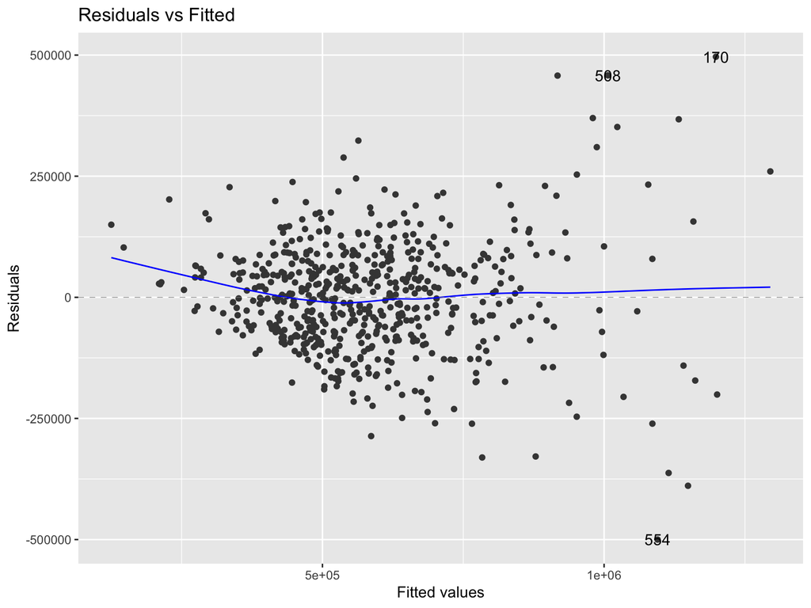

```r
autoplot(mdl_min_vars, which=1, nrow=1, ncol= 1)
```

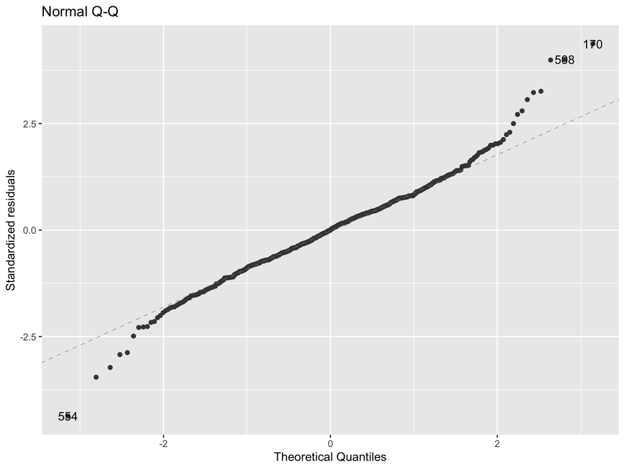

```r
autoplot(mdl_min_vars, which=2, nrow=1, ncol= 1)
```

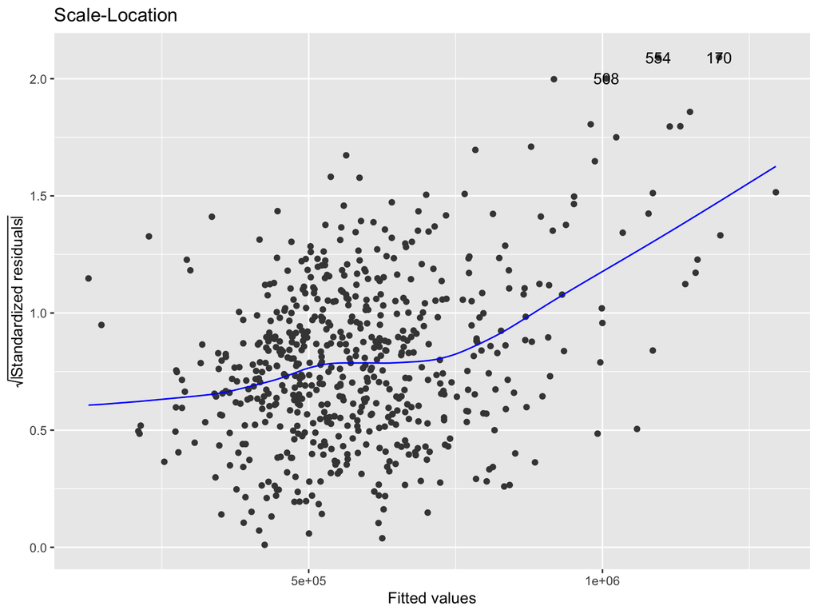

```r
autoplot(mdl_min_vars, which=3, nrow=1, ncol= 1)
```

# Modeling(4)

## Model with interactions

```r
mdl_min_vars_inter <- lm((price) ~ sqft_above + condition + sqft_living15 +yr_renovated+ sqft_living:floors
         + sqft_living:grade, kc_house_data)
summary(mdl_min_vars_inter)
```

```
##
## Call:
## lm(formula = (price) ~ sqft_above + condition + sqft_living15 +
##     yr_renovated + sqft_living:floors + sqft_living:grade, data = kc_house_data)
##
## Residuals:
##     Min      1Q  Median      3Q     Max
## -544129  -75223     243   72030  495497
##
## Coefficients:
##                      Estimate Std. Error t value Pr(>|t|)
## (Intercept)        -92056.368  36093.687  -2.550 0.011007 *
## sqft_above             81.135     20.797   3.901 0.000107 ***
## condition           24747.417   7014.700   3.528 0.000451 ***
## sqft_living15         161.426     18.882   8.549  < 2e-16 ***
## yr_renovated           23.943     10.827   2.211 0.027389 *
## sqft_living:floors    -36.015      5.355  -6.725 4.12e-11 ***
## sqft_living:grade      27.141      1.709  15.884  < 2e-16 ***
## ---
## Signif. codes:  0 '***' 0.001 '**' 0.01 '*' 0.05 '.' 0.1 ' ' 1
##
## Residual standard error: 117300 on 595 degrees of freedom
## Multiple R-squared:  0.6881, Adjusted R-squared:  0.685
## F-statistic: 218.8 on 6 and 595 DF,  p-value: < 2.2e-16
```

```r
car::vif(mdl_min_vars_inter)
```

```
## there are higher-order terms (interactions) in this model
## consider setting type = 'predictor'; see ?vif
```

```
##         sqft_above          condition      sqft_living15       yr_renovated
##           4.487506           1.167416           1.253247           1.056353
## sqft_living:floors  sqft_living:grade
##           3.623968           4.039569
```